# MPDW Pertemuan 2

irsyadparama

2024-09-02

# Pemanggilan *Packages*

```r
library(dplyr)
library(TTR)
library(forecast)
library(lmtest) #digunakan untuk uji formal pendeteksian autokorelasi
library(orcutt) #untuk membuat model regresi Cochrane-Orcutt
library(HoRM) #untuk membuat model regresi Hildreth-Lu
```

# Input Data

Data yang digunakan dalam kesempatan kali ini adalah data GDP Negara Middle East & North Africa periode tahun 1965-2023.

```r
#impor excel
library(readxl)
data <- read_excel("C:/Users/Irsyad Parama/Downloads/DATAMIDDLEEAST.xlsx")
data
```

```
## # A tibble: 59 × 2
##    Tahun           GDP
##    <dbl>         <dbl>
##  1  1965  33355527573.
##  2  1966  35719093594.
##  3  1967  38474318202.
##  4  1968  44168901220.
##  5  1969  49272971405.
##  6  1970  55493554807.
##  7  1971  63999373657.
##  8  1972  78443642841.
##  9  1973 107825541176.
## 10  1974 198498005682.
## # ℹ 49 more rows
```

# Eksplorasi Data

Sebelum melakukan regresi, akan diperlihatkan *plot time-series* dari data GDP Middle East & North Africa periode tahun 1965-2023

```r
#Membentuk objek time series
data.ts<-ts(data$GDP, start = 1965, end = 2023, frequency = 1)
data.ts
```

```
## Time Series:
## Start = 1965
## End = 2023
## Frequency = 1
##  [1] 3.335553e+10 3.571909e+10 3.847432e+10 4.416890e+10 4.927297e+10
##  [6] 5.549355e+10 6.399937e+10 7.844364e+10 1.078255e+11 1.984980e+11
## [11] 2.167780e+11 2.700730e+11 3.135083e+11 3.315150e+11 4.344475e+11
## [16] 5.602566e+11 5.736748e+11 5.727096e+11 5.818747e+11 5.860058e+11
## [21] 5.970812e+11 6.041678e+11 5.606886e+11 5.555221e+11 5.722450e+11
## [26] 7.451031e+11 5.493816e+11 6.003850e+11 6.105601e+11 6.466049e+11
## [31] 7.137381e+11 7.941794e+11 8.326572e+11 8.144717e+11 8.859726e+11
## [36] 9.925558e+11 9.874840e+11 9.793516e+11 1.090480e+12 1.286314e+12
## [41] 1.542092e+12 1.810948e+12 2.140272e+12 2.674261e+12 2.399658e+12
## [46] 2.820272e+12 3.396707e+12 3.660137e+12 3.601732e+12 3.627618e+12
## [51] 3.201010e+12 3.234259e+12 3.372000e+12 3.538057e+12 3.549945e+12
## [56] 3.199082e+12 3.780277e+12 4.497117e+12 4.287684e+12
```

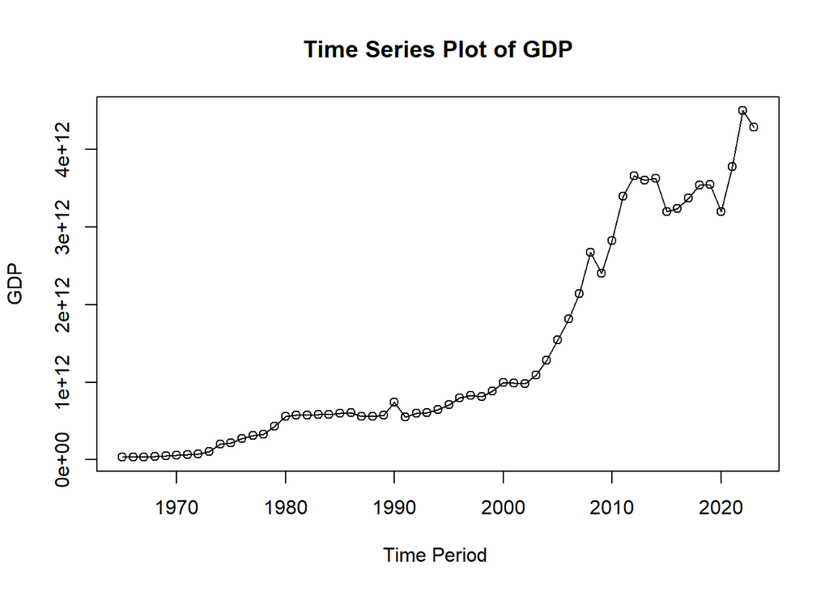

```r
#Membuat plot time series
ts.plot(data.ts, xlab="Time Period ", ylab="GDP", main= "Time Series Plot of GDP")
points(data.ts)
```

Selanjutnya akan dilakukan ramalan dan pemulusan dengan metode DMA dan DES karena terlihat pada plot di atas menunjukkan adanya *trend*.

```r
dt.sma <- SMA(data.ts, n=3)
dma <- SMA(dt.sma, n = 3)
At <- 2*dt.sma - dma
Bt <- 2/(3-1)*(dt.sma - dma)
dt.dma<- At+Bt
dt.ramal<- c(NA, dt.dma)

t = 1:5
f = c()

for (i in t) {
  f[i] = At[length(At)] + Bt[length(Bt)]*(i)
}
```

```r
dt.gab <- cbind(aktual = c(data.ts,rep(NA,5)),
                pemulusan1 = c(dt.sma,rep(NA,5)),
                pemulusan2 = c(dt.dma, rep(NA,5)),
                At = c(At, rep(NA,5)),
                Bt = c(Bt,rep(NA,5)),
                ramalan = c(dt.ramal, f[-1]))
dt.gab
```

```
##             aktual   pemulusan1   pemulusan2           At            Bt
##  [1,] 3.335553e+10           NA           NA           NA            NA
##  [2,] 3.571909e+10           NA           NA           NA            NA
##  [3,] 3.847432e+10 3.584965e+10           NA           NA            NA
##  [4,] 4.416890e+10 3.945410e+10           NA           NA            NA
##  [5,] 4.927297e+10 4.397206e+10 5.239898e+10 4.818552e+10    4213458808
##  [6,] 5.549355e+10 4.964514e+10 6.022122e+10 5.493318e+10    5288039002
##  [7,] 6.399937e+10 5.625530e+10 6.885090e+10 6.255310e+10    6297797942
##  [8,] 7.844364e+10 6.597886e+10 8.335037e+10 7.466461e+10    8685757257
##  [9,] 1.078255e+11 8.342285e+10 1.131639e+11 9.829337e+10   14870516019
## [10,] 1.984980e+11 1.282557e+11 1.996622e+11 1.639590e+11   35703250046
## [11,] 2.167780e+11 1.743672e+11 2.657377e+11 2.200524e+11   45685254522
## [12,] 2.700730e+11 2.284497e+11 3.313006e+11 2.798752e+11   51425482329
## [13,] 3.135083e+11 2.667864e+11 3.539571e+11 3.103718e+11   43585334958
## [14,] 3.315150e+11 3.050321e+11 3.815842e+11 3.433081e+11   38276031839
```

[output cut: 115 more lines]

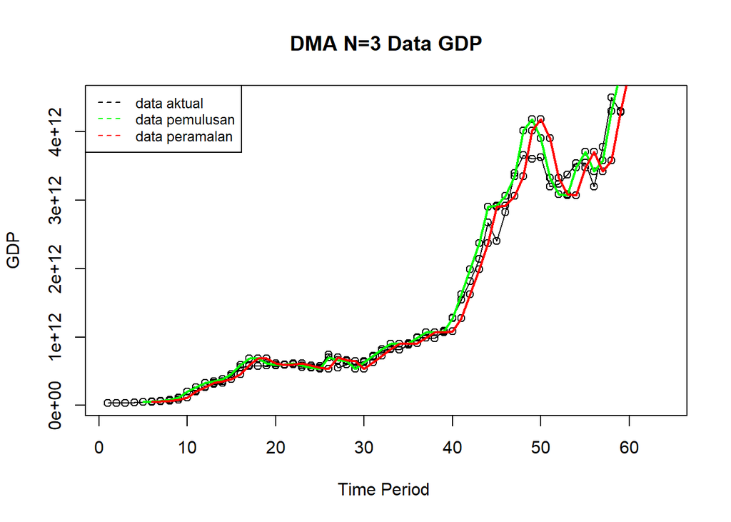

```r
#Plot time series
ts.plot(dt.gab[,1], xlab="Time Period ", ylab="GDP",
        main= "DMA N=3 Data GDP", ylim=c(33355527573,4497120000000))
points(dt.gab[,1])
points(dt.gab[,3])
points(dt.gab[,6])
lines(dt.gab[,3],col="green",lwd=2)
lines(dt.gab[,6],col="red",lwd=2)
legend("topleft",c("data aktual","data pemulusan","data peramalan"),
       lty=8, col=c("black","green","red"), cex=0.8)
```

Selanjutnya akan dilihat keakuratan dari metode DMA

```r
#Menghitung nilai keakuratan
error.dma = data.ts-dt.ramal[1:length(data.ts)]
SSE.dma = sum(error.dma[6:length(data.ts)]^2)
MSE.dma = mean(error.dma[6:length(data.ts)]^2)
MAPE.dma = mean(abs((error.dma[6:length(data.ts)]/data.ts[6:length(data.ts)])*100))

akurasi.dma <- matrix(c(SSE.dma, MSE.dma, MAPE.dma))
row.names(akurasi.dma)<- c("SSE", "MSE", "MAPE")
colnames(akurasi.dma) <- c("Akurasi m = 3")
akurasi.dma
```

```
##      Akurasi m = 3
## SSE   3.407001e+24
## MSE   6.309261e+22
## MAPE  1.059408e+01
```

Selanjutnya akan digunakan metode *Double Exponential Smoothing* dengan cara sebagai berikut.

Pertama akan data akan dibagi menjadi data *training* dan data *testing*.

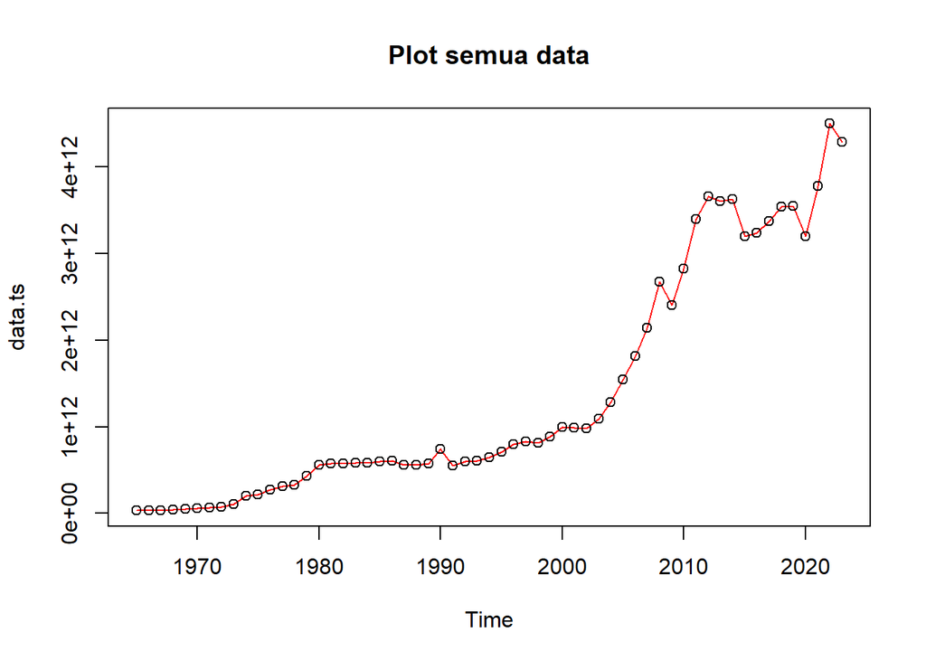

```r
#membagi training dan testing
training<-data[1:48,2]
testing<-data[49:60,2]

#data time series
training.ts<-ts(training)
testing.ts<-ts(testing,start=53)

#eksplorasi data
plot(data.ts, col="red",main="Plot semua data")
points(data.ts)
```

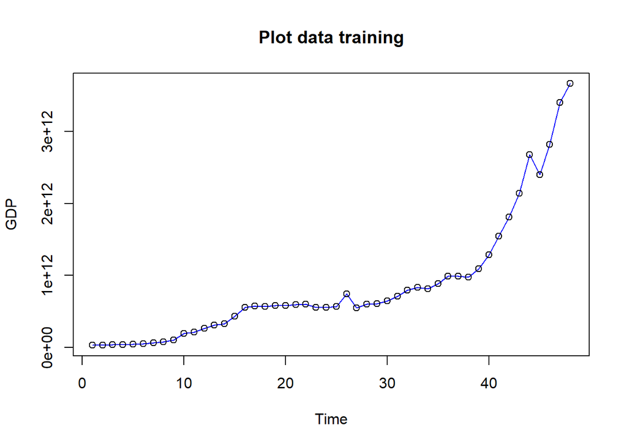

```r
plot(training.ts, col="blue",main="Plot data training")
points(training.ts)
```

Selanjutnya akan dilakukan pemulusan dengan DES, kali ini langsung dicari lambda dan gamma optimum sebagai berikut. Nilai lambda dan gamma optimum dapat dilihat pada smoothing parameters alpha untuk nilai lambda dan beta untuk nilai gamma.

```r
#Lamda dan gamma optimum
des.opt<- HoltWinters(training.ts, gamma = FALSE)
des.opt
```

```
## Holt-Winters exponential smoothing with trend and without seasonal component.
##
## Call:
## HoltWinters(x = training.ts, gamma = FALSE)
##
## Smoothing parameters:
##  alpha: 0.58199
##  beta : 0.4686026
##  gamma: FALSE
##
## Coefficients:
##           [,1]
## a 3.623633e+12
## b 3.436057e+11
```

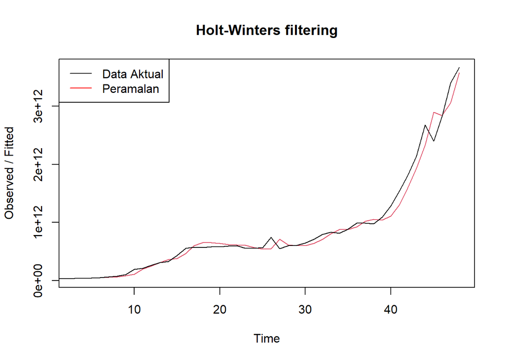

```r
plot(des.opt)
legend("topleft", c("Data Aktual", "Peramalan"), col = c("black", "red"),
       lty = c(1,1))
```